```python
import pandas as pd

# Load files
indicator = pd.read_csv('unicef_indicator_1_cleaned.csv')
metadata = pd.read_csv('unicef_metadata_cleaned.csv')

# Clean column names (very important)
indicator.columns = indicator.columns.str.strip().str.lower()
metadata.columns = metadata.columns.str.strip().str.lower()

# Merge based on 'country'
merged = pd.merge(indicator, metadata, on='country', how='left')

# Preview
merged.head()
```

|  | country | alpha_2_code_x | alpha_3_code_x | numeric_code_x | indicator | time_period | obs_value | sex | unit_of_measure | observation_status | ... | population, total | gdp per capita (constant 2015 us$) | gni (current us$) | inflation, consumer prices (annual %) | life expectancy at birth, total (years) | military expenditure (% of gdp) | fossil fuel energy consumption (% of total) | gdp growth (annual %) | birth rate, crude (per 1,000 people) | hospital beds (per 1,000 people) |
| --- | --- | --- | --- | --- | --- | --- | --- | --- | --- | --- | --- | --- | --- | --- | --- | --- | --- | --- | --- | --- | --- |
| 0 | Afghanistan | AF | AFG | 4 | Mortality rate age 10-14 | 1990 | 7.857009 | Female | Deaths per 1,000 children aged 10 | Normal value | ... | 9035043.0 | NaN | 5.488888e+08 | NaN | 32.535 | NaN | NaN | NaN | 50.340 | 0.170627 |
| 1 | Afghanistan | AF | AFG | 4 | Mortality rate age 10-14 | 1990 | 7.857009 | Female | Deaths per 1,000 children aged 10 | Normal value | ... | 9214083.0 | NaN | 5.600000e+08 | NaN | 33.068 | NaN | NaN | NaN | 50.443 | NaN |
| 2 | Afghanistan | AF | AFG | 4 | Mortality rate age 10-14 | 1990 | 7.857009 | Female | Deaths per 1,000 children aged 10 | Normal value | ... | 9404406.0 | NaN | 5.577778e+08 | NaN | 33.547 | NaN | NaN | NaN | 50.570 | NaN |
| 3 | Afghanistan | AF | AFG | 4 | Mortality rate age 10-14 | 1990 | 7.857009 | Female | Deaths per 1,000 children aged 10 | Normal value | ... | 9604487.0 | NaN | 7.666667e+08 | NaN | 34.016 | NaN | NaN | NaN | 50.703 | NaN |
| 4 | Afghanistan | AF | AFG | 4 | Mortality rate age 10-14 | 1990 | 7.857009 | Female | Deaths per 1,000 children aged 10 | Normal value | ... | 9814318.0 | NaN | 8.155556e+08 | NaN | 34.494 | NaN | NaN | NaN | 50.831 | NaN |

5 rows × 25 columns

```python
chosen = 'Mortality rate age 10-14'
data = merged[merged['indicator'] == chosen]
data.head()
```

|  | country | alpha_2_code_x | alpha_3_code_x | numeric_code_x | indicator | time_period | obs_value | sex | unit_of_measure | observation_status | ... | population, total | gdp per capita (constant 2015 us$) | gni (current us$) | inflation, consumer prices (annual %) | life expectancy at birth, total (years) | military expenditure (% of gdp) | fossil fuel energy consumption (% of total) | gdp growth (annual %) | birth rate, crude (per 1,000 people) | hospital beds (per 1,000 people) |
| --- | --- | --- | --- | --- | --- | --- | --- | --- | --- | --- | --- | --- | --- | --- | --- | --- | --- | --- | --- | --- | --- |
| 0 | Afghanistan | AF | AFG | 4 | Mortality rate age 10-14 | 1990 | 7.857009 | Female | Deaths per 1,000 children aged 10 | Normal value | ... | 9035043.0 | NaN | 5.488888e+08 | NaN | 32.535 | NaN | NaN | NaN | 50.340 | 0.170627 |
| 1 | Afghanistan | AF | AFG | 4 | Mortality rate age 10-14 | 1990 | 7.857009 | Female | Deaths per 1,000 children aged 10 | Normal value | ... | 9214083.0 | NaN | 5.600000e+08 | NaN | 33.068 | NaN | NaN | NaN | 50.443 | NaN |
| 2 | Afghanistan | AF | AFG | 4 | Mortality rate age 10-14 | 1990 | 7.857009 | Female | Deaths per 1,000 children aged 10 | Normal value | ... | 9404406.0 | NaN | 5.577778e+08 | NaN | 33.547 | NaN | NaN | NaN | 50.570 | NaN |
| 3 | Afghanistan | AF | AFG | 4 | Mortality rate age 10-14 | 1990 | 7.857009 | Female | Deaths per 1,000 children aged 10 | Normal value | ... | 9604487.0 | NaN | 7.666667e+08 | NaN | 34.016 | NaN | NaN | NaN | 50.703 | NaN |
| 4 | Afghanistan | AF | AFG | 4 | Mortality rate age 10-14 | 1990 | 7.857009 | Female | Deaths per 1,000 children aged 10 | Normal value | ... | 9814318.0 | NaN | 8.155556e+08 | NaN | 34.494 | NaN | NaN | NaN | 50.831 | NaN |

5 rows × 25 columns

**Spring 2025 • BAA1030 Data Analytics & Storytelling (20074)**  
**Student: Prabhjas Singh (ID 16815)**  
**Programme: MSc in Management (Strategy)**

[output not shown]

# Introduction

Adolescent health remains a critical, yet often overlooked, area of global public health.  
This report focuses on mortality among adolescents aged 10–14 years, using UNICEF's global dataset to highlight key patterns and inequalities.

**In this report, we will explore:**

- The top countries with the highest adolescent mortality rates
- Mortality rate trends over time in selected countries
- A global view of mortality distribution through mapping
- Key recommendations for future health policies

Understanding and addressing adolescent mortality is essential for achieving global development goals and building a healthier future generation.

# Mortality Rates by Gender in Top 10 Countries

The chart below compares mortality rates between male and female adolescents (ages 10–14) in the top 10 countries with the highest overall mortality.

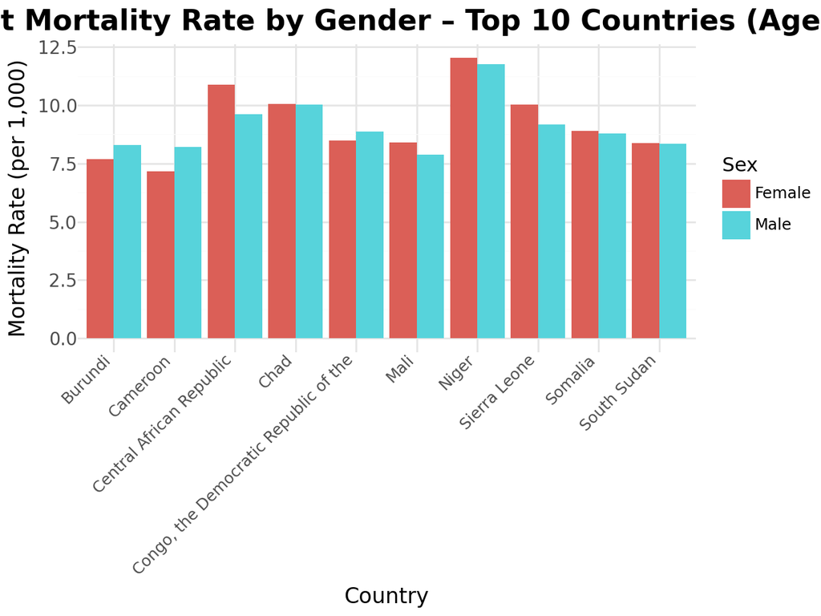

```python
# Step 1: Filter latest year
latest_year = data['time_period'].max()
latest_data = data[data['time_period'] == latest_year]

# Step 2: Remove 'Both sexes'
latest_data = latest_data[latest_data['sex'].isin(['Male', 'Female'])]

# Step 3: Pick top 10 countries (overall highest average mortality)
top10_countries = latest_data.groupby('country')['obs_value'].mean().sort_values(ascending=False).head(10).index.tolist()

# Step 4: Filter top 10 countries only
top10_gender_data = latest_data[latest_data['country'].isin(top10_countries)]

# Step 5: Plot
(
    ggplot(top10_gender_data) +
    aes(x='country', y='obs_value', fill='sex') +
    geom_bar(stat='identity', position='dodge') +  # side-by-side bars
    theme_minimal() +
    labs(
        title='Adolescent Mortality Rate by Gender – Top 10 Countries (Age 10–14)',
        x='Country',
        y='Mortality Rate (per 1,000)',
        fill='Sex'
    ) +
    theme(
        plot_title=element_text(size=16, face="bold"),
        axis_title_x=element_text(size=12),
        axis_title_y=element_text(size=12),
        axis_text_x=element_text(rotation=45, hjust=1),
        axis_text_y=element_text(size=10)
    )
)
```

# Mortality Rate Trends Over Time

Analyzing adolescent mortality rates over multiple years helps identify whether countries are making progress in improving health outcomes.

The line chart below shows the trend of mortality rates for Nigeria over the past years.

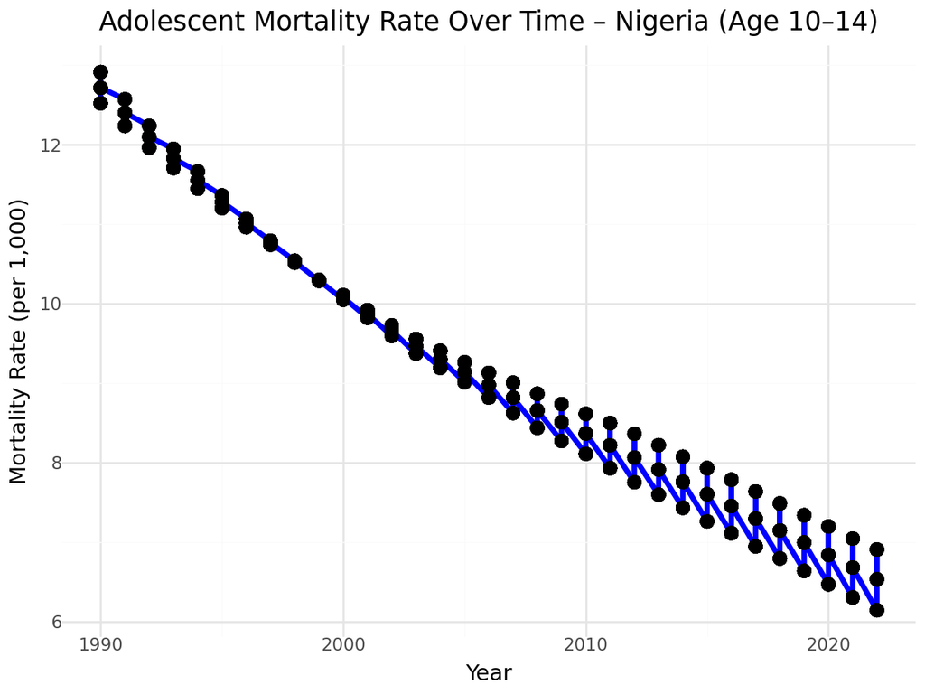

```python
# Filter data for Nigeria
nigeria = data[(data['country'] == 'Nigeria') & (data['time_period'] <= latest_year)]

# Plot Time Series Line Chart
(
    ggplot(nigeria) +
    aes(x='time_period', y='obs_value') +
    geom_line(color='blue', size=1.5) +
    geom_point(color='black', size=3) +
    theme_minimal() +
    labs(
        title='Adolescent Mortality Rate Over Time – Nigeria (Age 10–14)',
        x='Year',
        y='Mortality Rate (per 1,000)'
    )
)
```

# Global Distribution of Adolescent Mortality

The map below visualizes adolescent mortality rates across countries.

Higher mortality rates are concentrated in low- and middle-income regions, particularly in Sub-Saharan Africa and parts of South Asia, highlighting ongoing inequalities in global health access and outcomes.

```python
# Install Plotly if not already installed
!pip install plotly

import plotly.express as px

# Make sure country names are properly capitalized
data['country'] = data['country'].str.title()

# Filter latest year
latest_year = data['time_period'].max()
latest_global_data = data[data['time_period'] == latest_year]

# Plot World Map
fig = px.choropleth(
    latest_global_data,
    locations="country",
    locationmode="country names",
    color="obs_value",
    color_continuous_scale="Blues",
    title="Global Distribution of Adolescent Mortality Rates (Age 10–14)",
    labels={'obs_value': 'Mortality Rate (per 1,000)'}
)

fig.show()
```

[interactive chart not shown]

# Gender and Economic Disparities in Adolescent Mortality

**Key Insights:**

- Mortality rates tend to decrease with increasing national wealth.
- Males often exhibit slightly higher mortality rates compared to females across GDP levels.
- In wealthier countries, gender differences in mortality narrow significantly, indicating more equitable access to healthcare resources.

```python
import pandas as pd

# Load the datasets
indicator = pd.read_csv('unicef_indicator_1_cleaned.csv')
metadata = pd.read_csv('unicef_metadata_cleaned.csv')

# Clean the column names
indicator.columns = indicator.columns.str.strip().str.lower()
metadata.columns = metadata.columns.str.strip().str.lower()

# Filter Indicator 1 for the indicator you want
chosen = 'Mortality rate age 10-14'
data = indicator[indicator['indicator'] == chosen]

# Confirm
data.head()
```

|  | country | alpha_2_code | alpha_3_code | numeric_code | indicator | time_period | obs_value | sex | unit_of_measure | observation_status | current_age |
| --- | --- | --- | --- | --- | --- | --- | --- | --- | --- | --- | --- |
| 0 | Afghanistan | AF | AFG | 4 | Mortality rate age 10-14 | 1990 | 7.857009 | Female | Deaths per 1,000 children aged 10 | Normal value | Total |
| 1 | Afghanistan | AF | AFG | 4 | Mortality rate age 10-14 | 1991 | 7.138557 | Female | Deaths per 1,000 children aged 10 | Normal value | Total |
| 2 | Afghanistan | AF | AFG | 4 | Mortality rate age 10-14 | 1992 | 6.470121 | Female | Deaths per 1,000 children aged 10 | Normal value | Total |
| 3 | Afghanistan | AF | AFG | 4 | Mortality rate age 10-14 | 1993 | 5.878975 | Female | Deaths per 1,000 children aged 10 | Normal value | Total |
| 4 | Afghanistan | AF | AFG | 4 | Mortality rate age 10-14 | 1994 | 5.331355 | Female | Deaths per 1,000 children aged 10 | Normal value | Total |

```python
# Find the latest year
latest_year = data['time_period'].max()
print(latest_year)
```

```
2022
```

```python
# Merge mortality with GDP from metadata
data['country'] = data['country'].str.strip().str.title()
metadata['country'] = metadata['country'].str.strip().str.title()

# Merge datasets
merged_data = pd.merge(data, metadata[['country', 'gdp per capita (constant 2015 us$)']], on='country', how='left')

# Rename GDP column
merged_data.rename(columns={'gdp per capita (constant 2015 us$)': 'gdp'}, inplace=True)

# Filter for latest year
latest_gender_data = merged_data[(merged_data['time_period'] == latest_year) & (merged_data['sex'].isin(['Male', 'Female']))]

# Drop rows with missing GDP
latest_gender_data = latest_gender_data.dropna(subset=['gdp'])
```

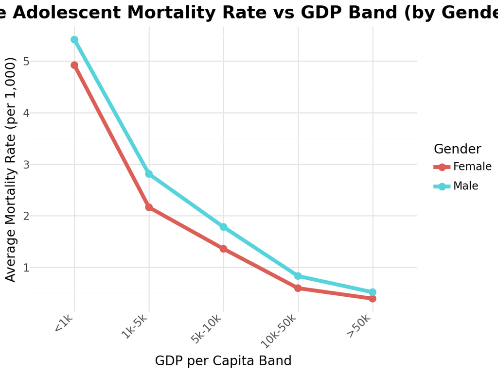

```python
# Create GDP Bands
bins = [0, 1000, 5000, 10000, 50000, 1000000]
labels = ['<1k', '1k-5k', '5k-10k', '10k-50k', '>50k']

latest_gender_data['gdp_band'] = pd.cut(latest_gender_data['gdp'], bins=bins, labels=labels)

# Group by GDP Band and Sex
avg_mortality = latest_gender_data.groupby(['gdp_band', 'sex'])['obs_value'].mean().reset_index()

# Plot Line Chart
(
    ggplot(avg_mortality) +
    aes(x='gdp_band', y='obs_value', group='sex', color='sex') +
    geom_line(size=2) +
    geom_point(size=3) +
    theme_minimal() +
    labs(
        title='Average Adolescent Mortality Rate vs GDP Band (by Gender)',
        x='GDP per Capita Band',
        y='Average Mortality Rate (per 1,000)',
        color='Gender'
    ) +
    theme(
        plot_title=element_text(size=16, face="bold"),
        axis_title_x=element_text(size=12),
        axis_title_y=element_text(size=12),
        axis_text_x=element_text(size=10, rotation=45, hjust=1),
        axis_text_y=element_text(size=10),
        legend_title=element_text(size=12),
        legend_text=element_text(size=10)
    )
)
```

```python
metadata.columns
```

```
Index(['country', 'alpha_2_code', 'alpha_3_code', 'numeric_code', 'year',
       'population, total', 'gdp per capita (constant 2015 us$)',
       'gni (current us$)', 'inflation, consumer prices (annual %)',
       'life expectancy at birth, total (years)',
       'military expenditure (% of gdp)',
       'fossil fuel energy consumption (% of total)', 'gdp growth (annual %)',
       'birth rate, crude (per 1,000 people)',
       'hospital beds (per 1,000 people)'],
      dtype='object')
```

# Conclusion

This report analyzed global adolescent mortality rates (ages 10–14) using UNICEF datasets, focusing on gender differences, regional disparities, and economic influences.

**Key Findings:**

**Recommendations:**

- Focus international healthcare resources on the most vulnerable regions.
- Strengthen early interventions and education targeted at adolescents.
- Promote global collaborations to reduce gender disparities and ensure equitable access to healthcare services for all adolescents.

Investing in adolescent health today will shape healthier, more resilient generations tomorrow.